# W3cubDocs

## Examples using `matplotlib.colors.LightSource`

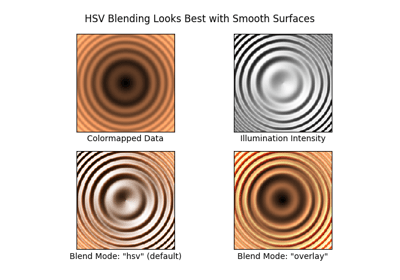

[Shading example](https://matplotlib.org/3.1.1/gallery/images_contours_and_fields/shading_example.html#sphx-glr-gallery-images-contours-and-fields-shading-example-py)

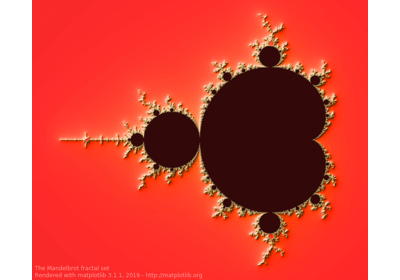

[Shaded & power normalized rendering](https://matplotlib.org/3.1.1/gallery/showcase/mandelbrot.html#sphx-glr-gallery-showcase-mandelbrot-py)

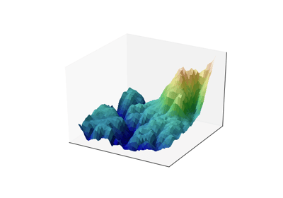

[Frontpage 3D example](https://matplotlib.org/3.1.1/gallery/frontpage/3D.html#sphx-glr-gallery-frontpage-3d-py)

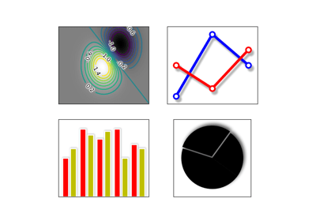

[Demo Agg Filter](https://matplotlib.org/3.1.1/gallery/misc/demo_agg_filter.html#sphx-glr-gallery-misc-demo-agg-filter-py)

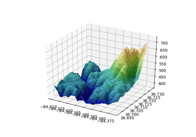

[Custom hillshading in a 3D surface plot](https://matplotlib.org/3.1.1/gallery/mplot3d/custom_shaded_3d_surface.html#sphx-glr-gallery-mplot3d-custom-shaded-3d-surface-py)

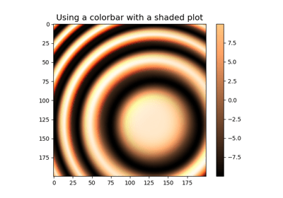

[Hillshading](https://matplotlib.org/3.1.1/gallery/specialty_plots/advanced_hillshading.html#sphx-glr-gallery-specialty-plots-advanced-hillshading-py)

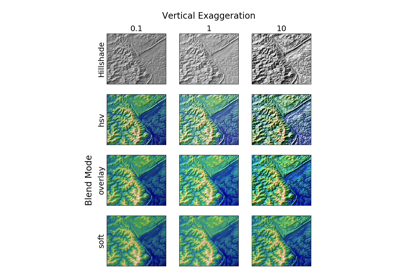

[Topographic hillshading](https://matplotlib.org/3.1.1/gallery/specialty_plots/topographic_hillshading.html#sphx-glr-gallery-specialty-plots-topographic-hillshading-py)